# practical_exercise_10 , Methods 3, 2021, autumn semester

Mikkel Kristensen

08-12-2021

# Exercises and objectives

#The code of the this portfolio assignment has been done in collaboration with the study group (Alina Kereszt (AK), Linus Backström (LB), Mikkel Kristensen (MK) and Mie Søgaard (MS)).

#The overall responsibility that each individual had for each section will be specified. The name and initials for the study group member who was overall responsible for a section will be specified. It should be noted, however, that the code in each section will vary a bit from study group member to study group member, and the explanations and comments have been individually written by each study group member.

1. Use principal component analysis to improve the classification of subjective experience
2. Use logistic regression with cross-validation to find the optimal number of principal components

REMEMBER: In your report, make sure to include code that can reproduce the answers requested in the exercises below (**MAKE A KNITTED VERSION**)  
REMEMBER: This is Assignment 4 and will be part of your final portfolio

# EXERCISE 1 - Use principal component analysis to improve the classification of subjective experience

We will use the same files as we did in Assignment 3 The files `megmag_data.npy` and `pas_vector.npy` can be downloaded here (http://laumollerandersen.org/data_methods_3/megmag_data.npy) and here (http://laumollerandersen.org/data_methods_3/pas_vector.npy)  
The function `equalize_targets` is supplied - this time, we will only work with an equalized data set. One motivation for this is that we have a well-defined chance level that we can compare against. Furthermore, we will look at a single time point to decrease the dimensionality of the problem

#Mie Søgaard (MS) 1) Create a covariance matrix, find the eigenvectors and the eigenvalues i. Load `megmag_data.npy` and call it `data` using `np.load`. You can use `join`, which can be imported from `os.path`, to create paths from different string segments

```python
import numpy as np
data = np.load("megmag_data.npy")
y = np.load("pas_vector.npy")
```

```
ii. Equalize the number of targets in `y` and `data` using `equalize_targets`
```

```python
def equalize_targets(data, y):
    np.random.seed(7)
    targets = np.unique(y)
    counts = list()
    indices = list()
    for target in targets:
        counts.append(np.sum(y == target))
        indices.append(np.where(y == target)[0])
    min_count = np.min(counts)
    first_choice = np.random.choice(indices[0], size=min_count, replace=False)
    second_choice = np.random.choice(indices[1], size=min_count, replace=False)
    third_choice = np.random.choice(indices[2], size=min_count, replace=False)
    fourth_choice = np.random.choice(indices[3], size=min_count, replace=False)

    new_indices = np.concatenate((first_choice, second_choice,
                                 third_choice, fourth_choice))
    new_y = y[new_indices]
    new_data = data[new_indices, :, :]

    return new_data, new_y

equalized = equalize_targets(data, y)
y_allequal = equalized[1]
X_allequal = equalized[0]
```

```
iii. Construct `times=np.arange(-200, 804, 4)` and find the index corresponding to 248 ms - then reduce the dimensionality of `data` from three to two dimensions by only choosing the time index corresponding to 248 ms (248 ms was where we found the maximal average response in Assignment 3)
```

```python
times = np.arange(-200, 804, 4)
hello = np.where(times==248) #It is at index 112

data_reduced = X_allequal[:, :, hello[0]]
data_reduced = np.reshape(data_reduced, (396, 102))
data_reduced
```

```
## array([[-2.78544623e-13, -1.39204262e-13,  3.27525848e-14, ...,
##         -4.22848555e-14,  2.55857589e-14, -1.52732032e-13],
##        [ 4.44614336e-13, -2.79207336e-13, -2.60503121e-13, ...,
##          2.54789234e-13,  6.81864439e-14,  1.93920229e-13],
##        [ 1.05656979e-13, -1.33122681e-13, -1.92785898e-13, ...,
##          4.64637073e-13,  2.27746678e-13, -6.83358870e-15],
##        ...,
##        [-9.58759092e-14, -1.12821585e-13, -4.03588943e-14, ...,
##          5.62321469e-13,  2.46699429e-13,  3.95857030e-13],
##        [ 3.55983791e-13,  1.22978868e-13,  9.66970552e-15, ...,
##         -8.04376420e-14, -1.14843270e-13, -3.13596910e-13],
##        [-2.61548458e-13,  1.51636830e-14,  7.18262059e-14, ...,
##          4.24462714e-13,  3.66191548e-13,  2.03528755e-13]])
```

```
iv. Scale the data using `StandardScaler`
```

```python
from sklearn.preprocessing import StandardScaler
scaledata = StandardScaler()

data_reduced_scaled = scaledata.fit_transform(data_reduced)
data_reduced_scaled
```

```
## array([[-0.46937261, -0.08652678,  0.51522368, ..., -0.14988534,
##          0.08210554, -0.25289215],
##        [ 1.8686806 , -0.69325466, -0.88473146, ...,  0.71323048,
##          0.22823791,  1.20559686],
##        [ 0.77279383, -0.06017119, -0.56146043, ...,  1.3229201 ,
##          0.77557451,  0.36095434],
##        ...,
##        [ 0.12121562,  0.02780717,  0.16620134, ...,  1.60673127,
##          0.84058779,  2.0552166 ],
##        [ 1.58212821,  1.0496898 ,  0.40502976, ..., -0.26073403,
##         -0.39960563, -0.92970775],
##        [-0.41442212,  0.58245378,  0.7017548 , ...,  1.20619795,
##          1.25047945,  1.24602334]])
```

```
v. Calculate the sample covariance matrix for the sensors (you can use `np.cov`) and plot it (either using `plt.imshow` or `sns.heatmap` (`import seaborn as sns`))
```

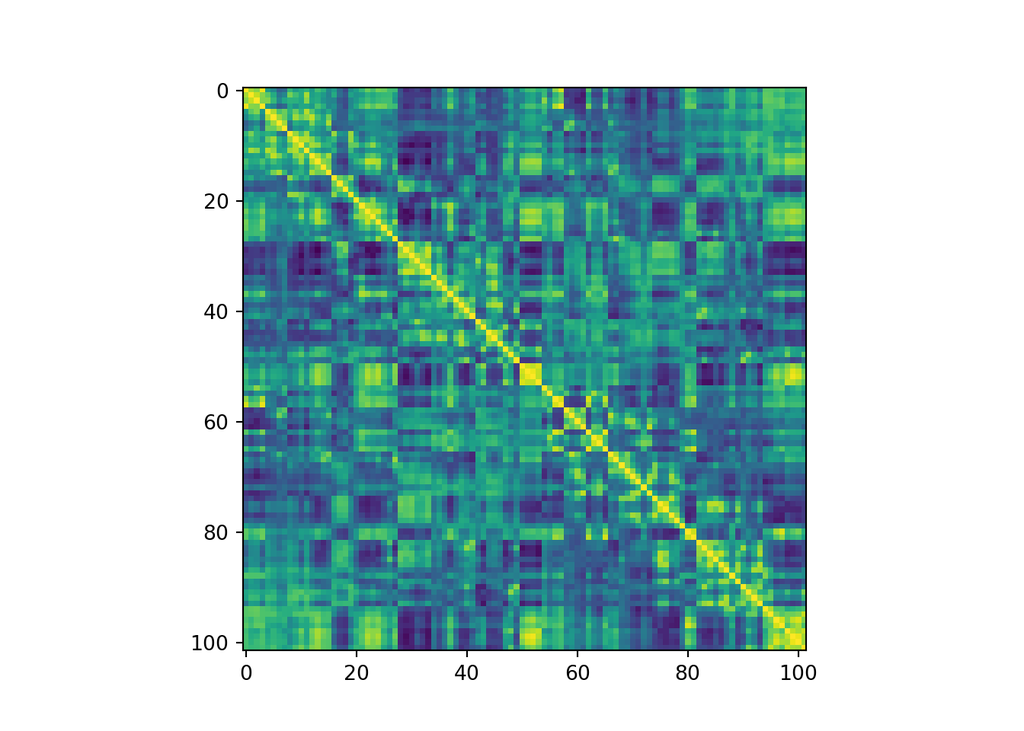

[output not shown]

```python
import matplotlib.pyplot as plt
cov = data_reduced_scaled.T @ data_reduced_scaled

plt.figure()
plt.imshow(cov)
plt.show()
```

```python
#If the diagonal of the covariance matrix were to be perfect, i.e. if the off-diagonal would not have any value, it would mean that each sensor co-varied with itself perfectly and none of the sensors would co-vary with each other. However, the plot above does show off-diagonal activation, which means that the sensors covary with each other. In other words, the sensors are not entirely independent of each other.
```

```
vii. Run `np.linalg.matrix_rank` on the covariance matrix - what integer value do you get? (we'll use this later)
```

```python
np.linalg.matrix_rank(cov)
#I get the value 97
```

```
## 97
```

[output not shown]

```python
eigen_vals, eigen_vecs = np.linalg.eig(cov)
print('\nEigenvalues \n%s' % eigen_vals)
```

```
##
## Eigenvalues
## [ 1.13347786e+04  6.38052653e+03  4.72687922e+03  2.81218855e+03
##   2.58234597e+03  1.40818984e+03  1.29057788e+03  1.08504249e+03
##   1.02029264e+03  8.13440630e+02  6.98519131e+02  5.24167347e+02
##   4.34817607e+02  4.12377231e+02  3.72499928e+02  3.33285787e+02
##   2.98641539e+02  2.57077761e+02  2.39568790e+02  2.11723061e+02
##   1.95398140e+02  1.58021283e+02  1.40430491e+02  1.30200902e+02
##   1.22230639e+02  1.15280842e+02  1.04750347e+02  1.01159135e+02
##   9.71795363e+01  9.29000866e+01  8.52359993e+01  8.35519483e+01
##   8.00151604e+01  7.23275969e+01  7.05498667e+01  6.46687901e+01
##   5.82792944e+01  5.65576466e+01  5.61593950e+01  5.34109215e+01
##   5.13956025e+01  4.92971683e+01  4.84838943e+01  4.49223531e+01
##   4.36902750e+01  4.08335370e+01  3.95973037e+01  3.81618168e+01
##   3.64341185e+01  3.52206303e+01  3.47739105e+01  3.31058685e+01
##   3.14067239e+01  2.98899840e+01  2.96269669e+01  2.88121514e+01
##   2.83425373e+01  2.70281834e+01  2.57932541e+01  2.53041400e+01
##   2.36566878e+01  4.15777799e+00  2.25639878e+01  2.22614683e+01
##   2.18062362e+01  2.12602025e+01  2.09633294e+01  2.04564838e+01
##   1.93571076e+01  1.88795615e+01  1.84668423e+01  5.30106486e+00
##   5.54893393e+00  1.68955739e+01  1.63683789e+01  1.60929607e+01
##   1.57970796e+01  1.54056892e+01  1.47232110e+01  6.19329589e+00
##   6.36402984e+00  6.92493270e+00  7.09586340e+00  7.49605728e+00
##   1.36009448e+01  1.32893323e+01  1.25500188e+01  1.21970501e+01
##   8.26286295e+00  1.16784589e+01  1.12229684e+01  1.07269049e+01
##   8.74182753e+00  9.22231487e+00  9.47462500e+00  9.76173963e+00
##   9.86518841e+00 -3.57315974e-13 -2.28198846e-13  7.61356665e-15
##  -2.27964002e-14 -5.06970271e-14]
```

#Linus Backström (LB)